# Silk investment related analyses for *The web architecture, dynamics, and silk investment in the social spider, Stegodyphus sarasinorum*

Thejasvi

Date of document initiation: Tuesday, March 29, 2016

*This is one of three Rmd files accompanying the manuscript. The other files are ‘beleyur_et_al_topology_analyses.Rmd’ (analyses the coordination number and pore size data), ‘weight_loss_analysis.Rmd’ (analyses weight loss of individuals across colonies over the experiment)*

##### You are reading a version of the report compiled on Sun Apr 4 00:37:24 2021

Spiders were kept in 4 group sizes (1,5,10,25) and allowed to build webs on a 2x2feet wire frame. Using a custom-modified version of Angioquant, a freely available MATLAB toolbox, I extracted skeletonised forms of these webs over multiple spatial resolutions over the period of the experiment.

### The dataset being analysed ‘skeletondata,csv’ has the following column headers:

### 1)colonyname 2)groupsize 3)Image name 4) Length of silk in grid 5) Number of junctions in grid

### 6)Serial number of grid (arranged column-wise from top-to-bottom) 7)Overal grid dimensions (eg. 32 means a 32x32 grid) 8) day, serial number of the reading from the start of experiment

### Removing some spiders from the dataset

I only realised a couple of days ago that there are still some colonies which have ‘extra’ spiders in them. These extra spiders appear because the spiders somehow managed to move between webs despite our best efforts. These colonies will now be removed from the dataset.

```r
excess_spiders <- read.csv('excess_spiders.csv')
colonies_to_remove <- subset(excess_spiders, excess_spiders_observed==TRUE)$colonyname


#load function which removes all rows in the colonynames list/vector
source('remove_colonies.R')
```

### A quick view of all the data together

###*Plot 1: Length of silk vs time: Whole data :*

```
## [1] 181  11
## [1] 175  11
## [1] 175  11
## [1] 166  11
## [1] 166  11
## [1] 159  11
## [1] 159  11
## [1] 152  11
```

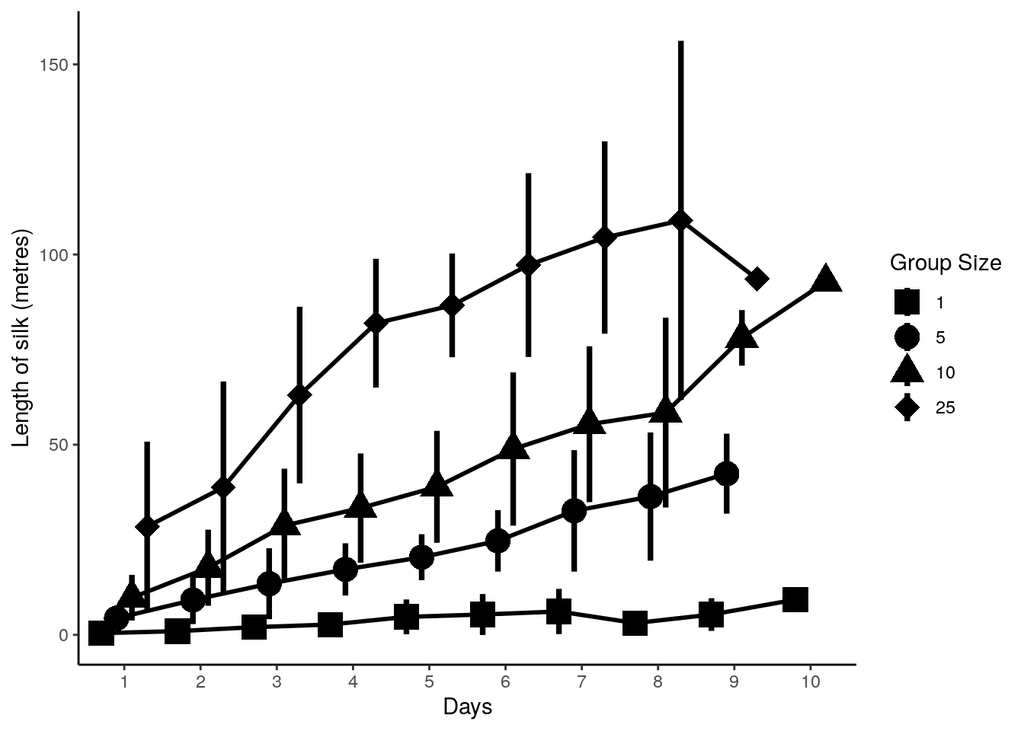

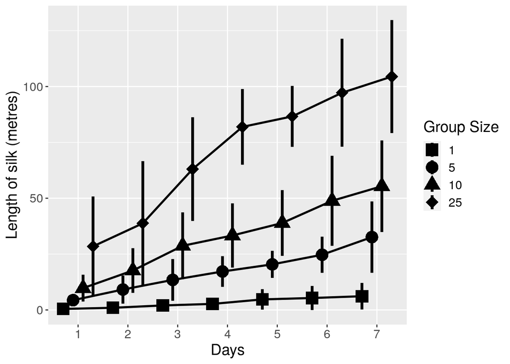

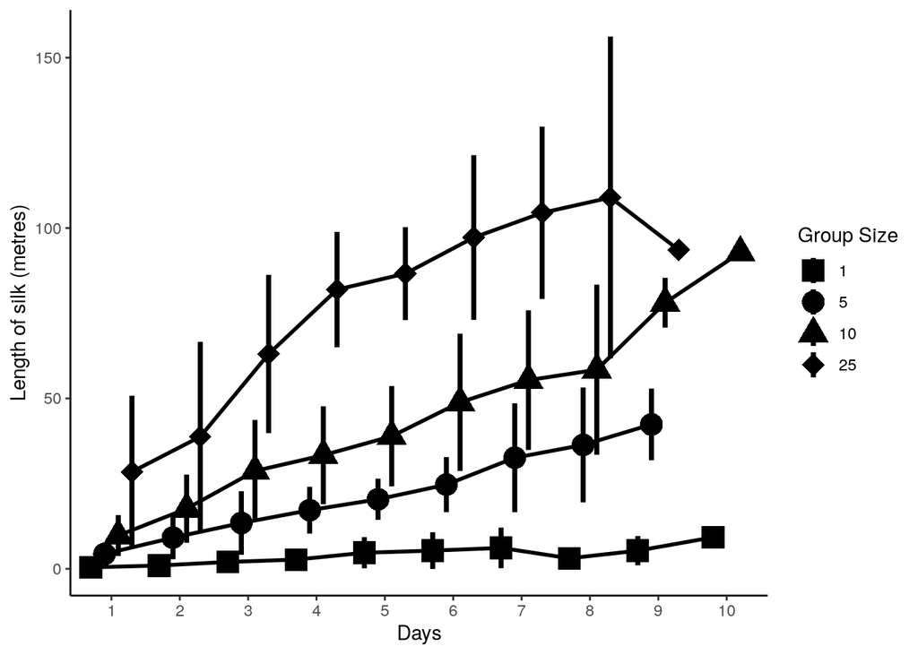

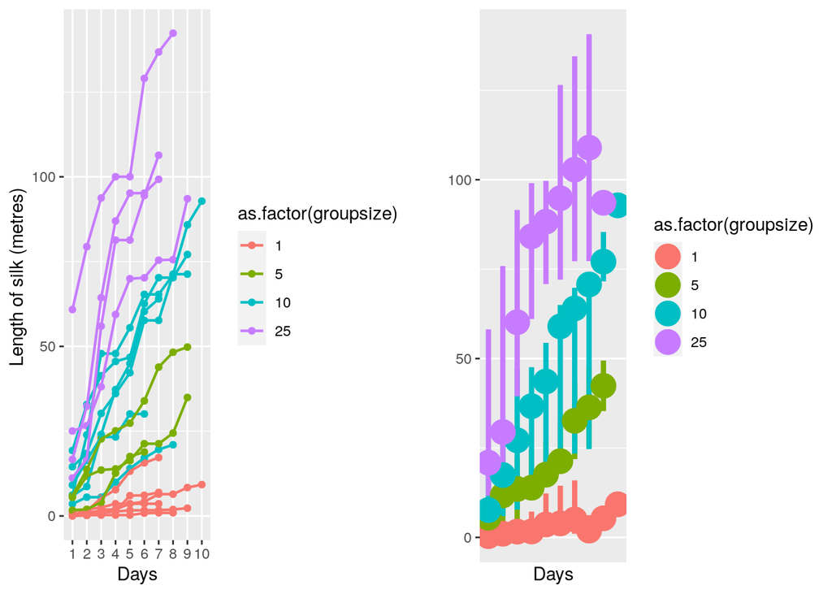

#### There seems to be a decent amount of overlap in silk investment across group sizes - but the 25 spider group seems to be quite distinct. This points to quite a bit of colony level variation.

### Experiment sample sizes

How many colonies of each group size were there, and the range of experiment duration.

```r
library(stringi)
t <- table(wd$colonyname)
colonynames <- dimnames(t)[[1]]
groupsizes <- vector(length=length(colonynames))
i = 1
for (each in colonynames)
{groupsizes[i] = stri_sub(each,from=1,to=-2);
  i = i+1}

# number of colonies per group-size
print(table(groupsizes))
```

```
## groupsizes
##  1 10 25  5
##  6  6  4  3
```

```r
# range of days for each group-size
print(t)
```

```
##
## 10B 10C 10D 10E 10F 10G  1A  1B  1C  1D  1F  1G 25A 25D 25F 25G  5E  5F  5H
##   8  10   6   9   9   7   7   8  10   9   7   7   7   9   8   7   9   9   6
```

| Groupsize | Ncolonies | Experiment range (days) |
| --- | --- | --- |
| 1 | 6 | 7-10 |
| 5 | 3 | 6-9 |
| 10 | 6 | 6-10 |
| 25 | 4 | 7-9 |

### *Plot 2*: How does the amount of silk scale with groupsize across time ?

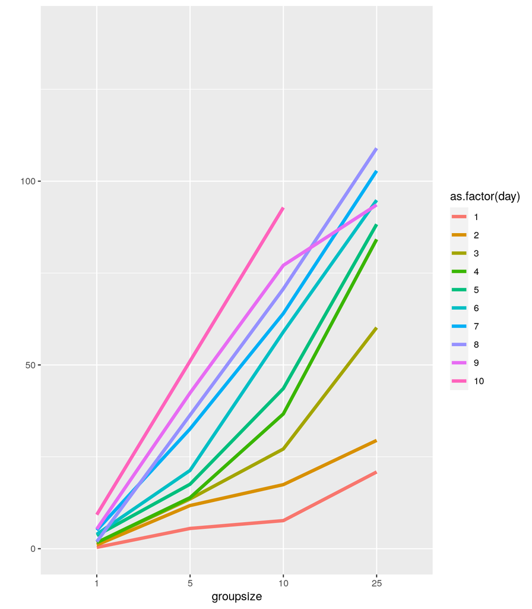

```r
#   SHOWS THE MEDIAN VALUE AT TIME WITH GROUP-SIZE ON X-AXIS
daywiseplots<-ggplot(wd,aes(x=as.factor(groupsize),y=Length/pixpm,color=as.factor(day),group=as.factor(day)))  + stat_summary(fun.y = median,fun.ymin=q025,fun.ymax=q975,size=1.5,geom='line') +ylab('')+xlab('groupsize')+scale_x_discrete(breaks=c(1,5,10,25),labels=c(1,5,10,25))
daywiseplots
```

```r
ps<-ps+1
```

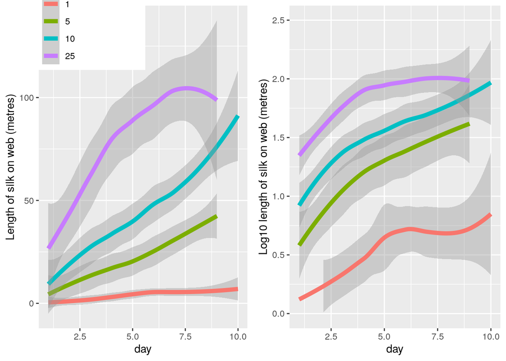

```r
M1p<-ggplot(wd,aes(x=day,y=log10(Length/pixpm+0.001),color=as.factor(groupsize),group=groupsize))+geom_smooth(lwd=2)+ylim(0,2.5)+ylab('Log10 length of silk on web (metres)')+theme(legend.position='none')

 M2p<-ggplot(wd,aes(x=day,y=Length/pixpm,color=as.factor(groupsize),group=groupsize))+geom_smooth(lwd=2)+ylab('Length of silk on web (metres)')+theme(legend.position=c(0.25,0.95))

multiplot(M2p,M1p,cols=2)
```

### *Plot 3* : $$ silk investment over time:

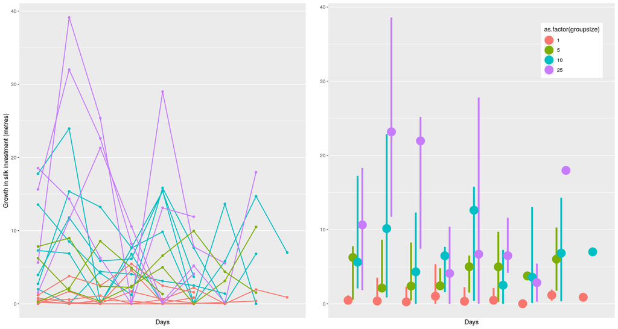

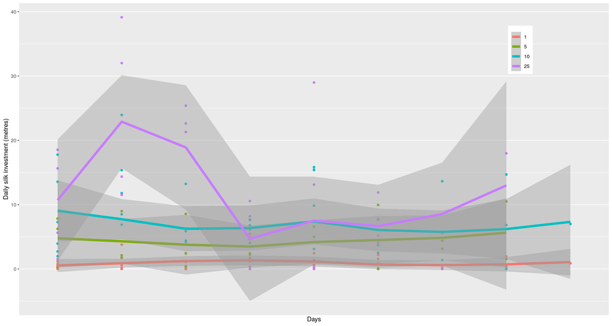

### *Plot 4* : Per Capita $$ silk investment :

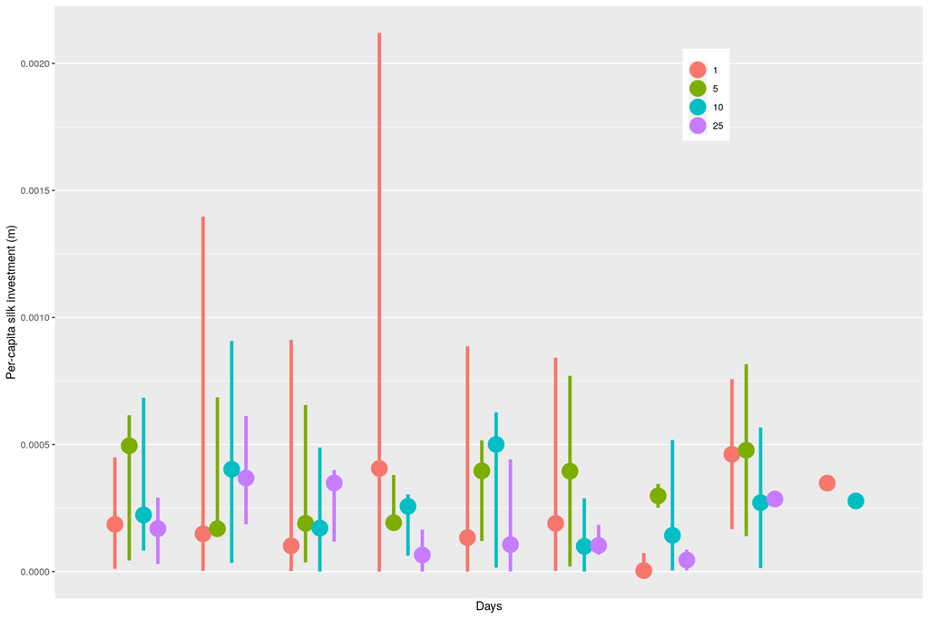

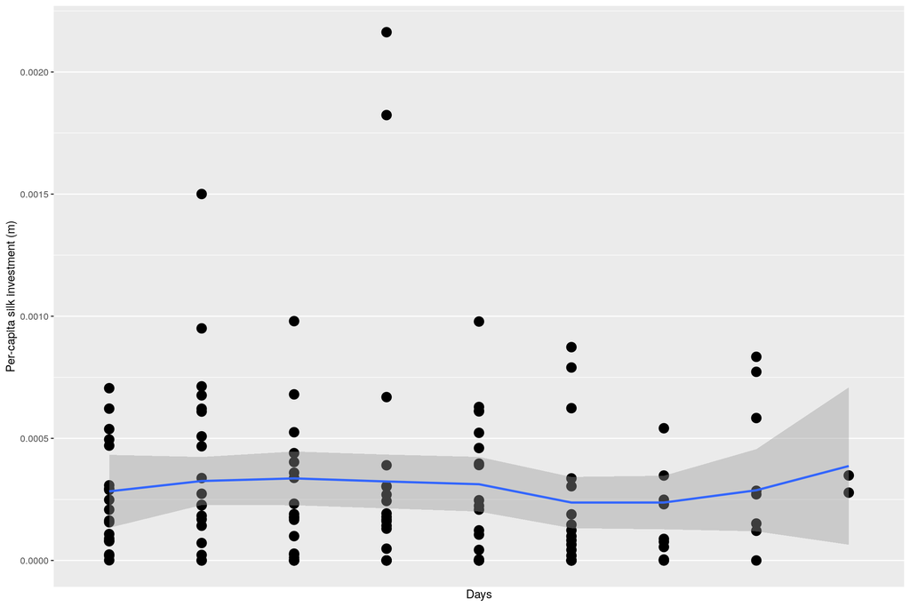

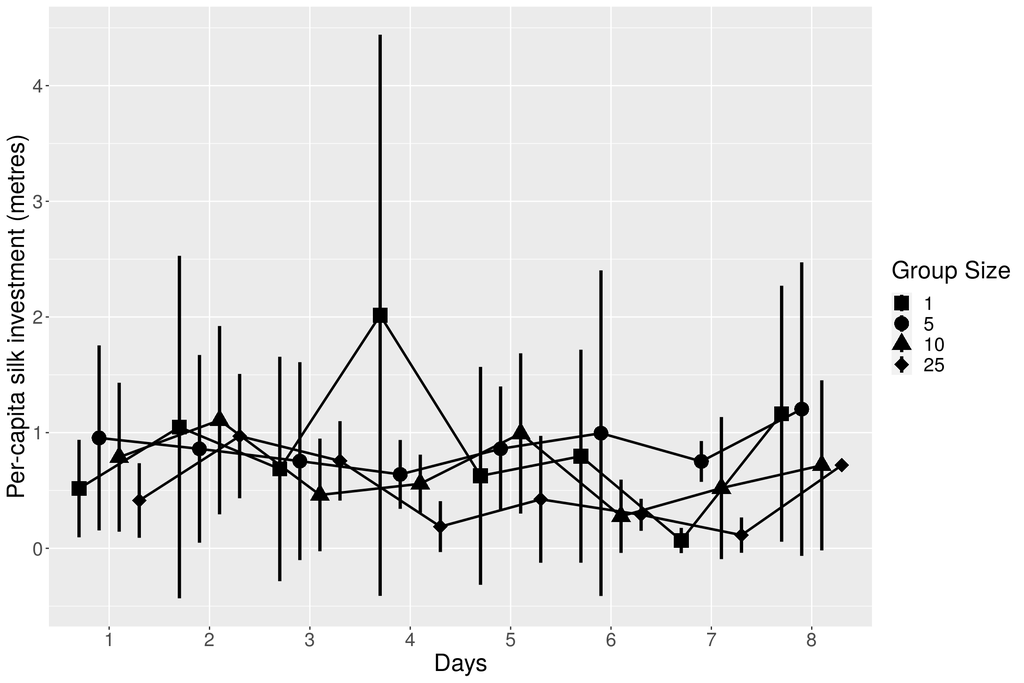

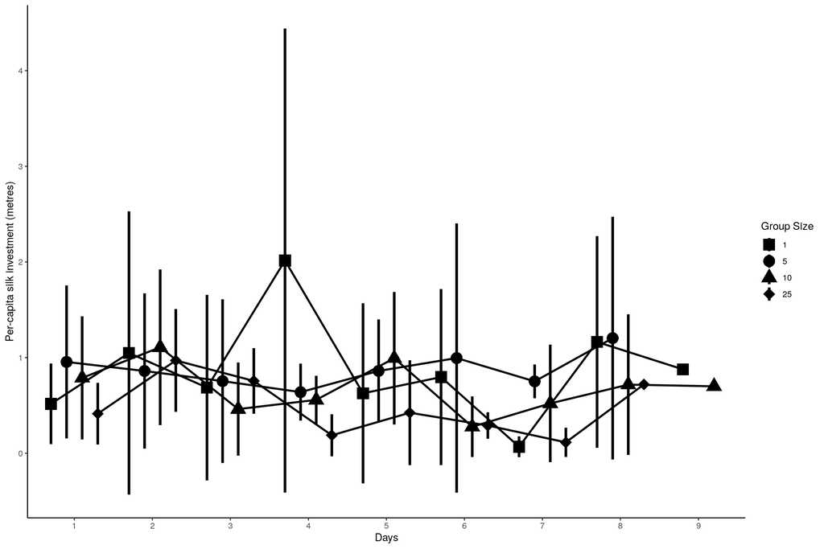

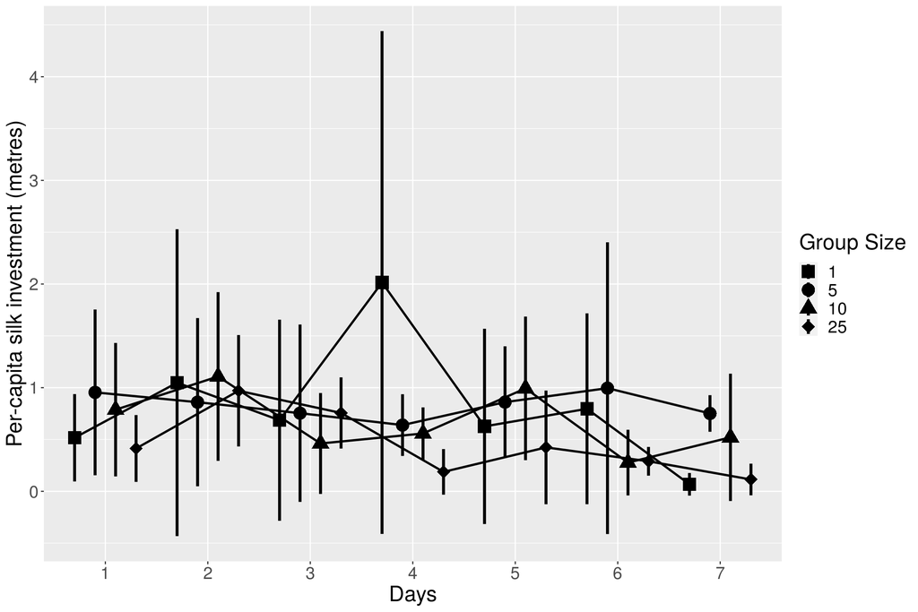

### Running the nparLD analysis

The nparLD analysis must be run with an older version of R (here I’m using 2.15.3). To do so, I’m using the Renv (https://github.com/viking/Renv) and R-build https://github.com/viking/R-build projects. For a description of how to do this - please see the topology analysis file.

```r
# this activates Renv. Make sure the default R version is set to 2.15.3
# this is a Linux specific way to do it
save(dlenth, file='dlenth.Rdata')
save(wd, file='wd.Rdata')

system('bash -c "source ~/.bash_profile"')
system('bash -c "Rscript silk_nparLD.R"')

# also - don't worry about the 'warning :covariance matrix is singular' -
# pers comm from 1st author off the package that it doesn't affect the results of the test

load('percapita_nparld_results.Rdata')

print(res$ANOVA.test)
```

```
##               Statistic       df   p-value
## groupsize     0.6386685 2.202461 0.5426393
## day           0.5585402 2.551899 0.6141796
## groupsize:day 0.6767252 4.537403 0.6266121
```

```r
# also load the overall silk nparlD results
load('overallsilk_nparLD_results.Rdata')
print(overall_silk$ANOVA.test)
```

```
##                Statistic       df      p-value
## groupsize     30.8828226 2.753718 1.592133e-18
## day           50.4293710 1.790491 1.542899e-20
## groupsize:day  0.8768285 3.836053 4.732244e-01
```

### Other general descriptive statistics in the paper

#### Number of replicates per group size

```r
wd1<-subset(wd, day==1)
table(wd1$groupsize)
```

```
##
##  1  5 10 25
##  6  3  6  4
```